# Forecasting football injuries by combining screening, monitoring and machine learning - 2/2 Data analysis

Anne Hecksteden & Georges Pierre Schmartz

28 March 2022

# Read Me

This is an R Markdown document which provides reproducible code for the core analyses discussed in the manuscript “Forecasting football injuries by combining screening, monitoring and machine learning”. The preparatory steps (data handling and feature engineering) are presented in the supplementary Markdown document 1/2.

Note 1: The densely commented code in this document aims to optimize transparency and accessibility - not efficiency of coding and computation.

Note 2: Only the upsampled training sets are shared due to the challenges of effectively anonymizing raw data.

# Loading raw data

```r
# clean workspace if needed
rm(list = ls())
ggplot_theme<-theme_bw()

# load prepared dataset
load("data_analyse.RData")
data <- data_analyse
```

# Epidemiologal description

## Incidence of acute, non-contact, time-loss injuries

There are 51 criterion injuries in the final dataset.

```r
# Incidence of criterion injuries (per 1000 hours of exposure)
## Overall
table(data$Crit)
```

```
##
## FALSE  TRUE
## 17167    51
```

```r
Training_time_overall <- sum(data$Training_time)/60

Incidence_overall <- (sum(data$Crit) / (Training_time_overall/1000))

table(data$Crit, data$Matchday)
```

```
##
##         FALSE  TRUE
##   FALSE 14342  2825
##   TRUE     35    16
```

```r
data_match <- filter(data, Matchday )
data_training <- filter(data, !Matchday )

Training_time_match <- sum(data_match$Training_time)/60
Training_time_match
```

```
## [1] 4323.935
```

```r
Training_time_training <- sum(data_training$Training_time)/60
Training_time_training
```

```
## [1] 19263.04
```

```r
Incidence_match <- (sum(data_match$Crit) / (Training_time_match / 1000))
Incidence_training <- (sum(data_training$Crit) / (Training_time_training / 1000))

Inc <- c(Incidence_overall, Incidence_match, Incidence_training)
Incidence <- as.data.frame(Inc)
Incidence <- as.data.frame(t(Incidence))
colnames(Incidence) <- c("Overall", "Match", "Training")

kable(Incidence, caption = "Incidence of criterion injuries per 1000 hours of exposure", digits = 2, align = "c")
```

Incidence of criterion injuries per 1000 hours of exposure

|  | Overall | Match | Training |
| --- | --- | --- | --- |
| Inc | 2.16 | 3.7 | 1.82 |

## Incidence of time-loss injuries

As recommended for comparison with other studies. There are 93 time-loss injuries in the final dataset

```r
# Incidence of time-loss injuries (per 1000 hours of exposure)
## Overall
table(data$TL_injury)
```

```
##
## FALSE  TRUE
## 17125    93
```

```r
Training_time_overall <- sum(data$Training_time)/60
Incidence_overall <- (sum(data$TL_injury) / (Training_time_overall/1000))

table(data$TL_injury, data$Matchday)
```

```
##
##         FALSE  TRUE
##   FALSE 14325  2800
##   TRUE     52    41
```

```r
data_match <- filter(data, Matchday )
data_training <- filter(data, !Matchday)

Training_time_match <- sum(data_match$Training_time)/60
Training_time_match
```

```
## [1] 4323.935
```

```r
Training_time_training <- sum(data_training$Training_time)/60
Training_time_training
```

```
## [1] 19263.04
```

```r
Incidence_match <- (sum(data_match$TL_injury) / (Training_time_match / 1000))
Incidence_training <- (sum(data_training$TL_injury) / (Training_time_training / 1000))

Inc <- c(Incidence_overall, Incidence_match, Incidence_training)
Incidence <- as.data.frame(Inc)
Incidence <- as.data.frame(t(Incidence))
colnames(Incidence) <- c("Overall", "Match", "Training")

kable(Incidence, caption = "Incidence of time-loss injuries per 1000 hours of exposure", digits = 2, align = "c")
```

Incidence of time-loss injuries per 1000 hours of exposure

|  | Overall | Match | Training |
| --- | --- | --- | --- |
| Inc | 3.94 | 9.48 | 2.7 |

# Main analysis

## Train-test split

Allocation by player, maintain proportion of players who sustain a criterion injury vs. those who do not (“Victim”).

```r
# Get set of "unique" IDs
data_unique <- distinct(data, ID, .keep_all = TRUE)

#Get IDs for train and test sets
tr_prop = 0.75    # proportion of full dataset to use for training

training_set = ddply(data_unique, .(Victim), function(., seed) { set.seed(seed); .[sample(1:nrow(.), trunc(nrow(.) * tr_prop)), ] }, seed = 42)

training_IDs <- as.vector(training_set$ID)

#change all boolean variables to factors for ROSE algorithm
boolean_cols<-setNames(as.logical(lapply(data,is.logical)),colnames(data))
data[boolean_cols]<-lapply(data[boolean_cols],factor,labels = c("No","Yes"),levels = c(F,T))

# Use vector with training IDs to split full dataset
data_training <- filter(data, ID %in% training_IDs)
data_test <- filter(data, !(ID%in% training_IDs))

# Check for size and number of "victims"
table(data_unique$Victim)
```

```
##
## FALSE  TRUE
##    49    39
```

```r
table(data_training$Victim)
```

```
##
##   No  Yes
## 6472 6192
```

```r
table(data_test$Victim)
```

```
##
##   No  Yes
## 2349 2205
```

```r
# Subset to variables used in the model (reduce number of variables for upsampling and remove "Victim")
subset <- c("ID", "Crit", "After_RTP", "Age", "Pos_code", "VV_resid_age", "Fat", "IAT", "Sprint_30", "SIMS_score", "SIMS_pain", "Srpe_7d_robust", "Matchday", "Srpe_team_avg", "KEB_AB_robust")

# Alternative subset monitoring +
#subset <- c("ID", "Crit", "After_RTP", "Age", "Pos_code", "VV_resid_age", "Srpe_7d_robust", "Matchday", "Srpe_team_avg", "KEB_AB_robust")

# Alternative subset monitoring only
# subset <- c("ID", "Crit", "After_RTP", "Srpe_7d_robust", "Matchday", "Srpe_team_avg", "KEB_AB_robust")

data_training <- subset(data_training, select = subset)
```

## Upsampling

To compensate for the marked underrepresentation of the minority class (days with occurence of a criterion injury) a balanced, synthetic training set is generated by upsampling the original training set according to the ROSE method.

```r
# Upsampling with ROSE
data_training_rose <- ROSE(Crit ~ ., data = data_training, N = 50000, seed = 42)$data

# Generate cross-validation folds index and remove ID
CV_folds<-groupKFold(data_training_rose$ID, k = 65)
data_training_rose<-select(data_training_rose, !ID)

# Check
table(data_training_rose$Crit)
```

```
##
##    No   Yes
## 24951 25049
```

## Fit gradient boosted model

Model fitting with leave-one-player-out stratified cross-validation using the upsampled training set.

```r
# Work with multiple threads (use half of the available ones)
cl <- makePSOCKcluster(ceiling(detectCores()/2))
registerDoParallel(cl)

trainctrl <- trainControl(method = "repeatedcv", number = 65, repeats = 10, summaryFunction = twoClassSummary, classProbs = TRUE, savePredictions = TRUE, index=CV_folds)

gbmGrid <-    expand.grid(interaction.depth = 2^(0:3),
                          n.trees = (1:8)*25,
                          shrinkage = 0.1,
                          n.minobsinnode = 10)

set.seed(42)
gbm_tree_auto <- train(Crit ~ ., data = data_training_rose, method = "gbm", metric = "ROC", trControl = trainctrl, verbose = FALSE, tuneGrid = gbmGrid)
#End concurrent section
stopCluster(cl)
registerDoSEQ()

# Show model
gbm_tree_auto
```

```
## Stochastic Gradient Boosting
##
## 50000 samples
##    13 predictor
##     2 classes: 'No', 'Yes'
##
## No pre-processing
## Resampling: Cross-Validated (65 fold, repeated 10 times)
## Summary of sample sizes: 48864, 49434, 47114, 48791, 48001, 48925, ...
## Resampling results across tuning parameters:
##
##   interaction.depth  n.trees  ROC        Sens       Spec
##   1                   25      0.6185722  0.6305670  0.4357457
##   1                   50      0.6492068  0.6532950  0.5126134
##   1                   75      0.6605125  0.6579314  0.5238241
```

[output cut: 36 more lines]

### Get cross-validation performance metrics

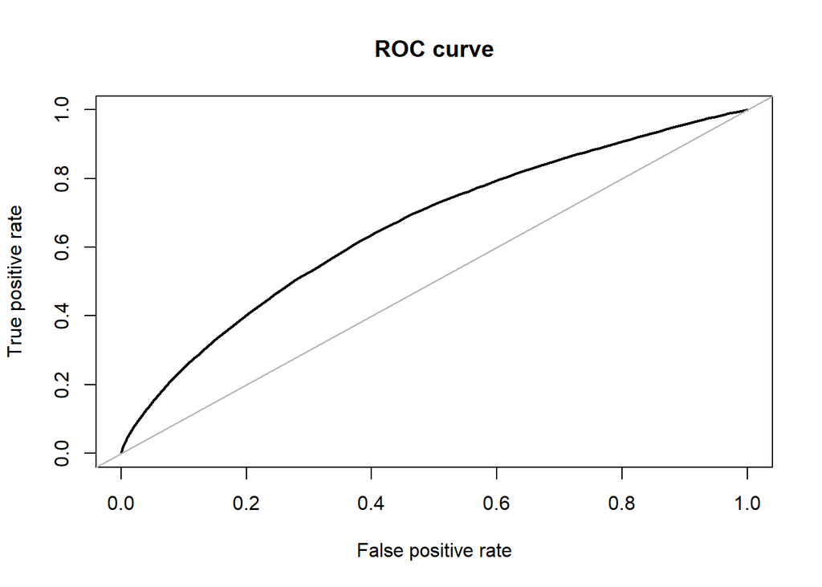

```r
# Extract from fit object
predicted <- as.data.frame(gbm_tree_auto$pred$pred)
observed <- as.data.frame(gbm_tree_auto$pred$obs)
prob_no <- as.data.frame(gbm_tree_auto$pred$No)
prob_yes <- as.data.frame(gbm_tree_auto$pred$Yes)

# ROC curve and AOC
cv_roc <- cbind(predicted, observed, prob_no, prob_yes)
names(cv_roc) <- c("pred", "obs", "prob_no", "prob_yes")


cv_roc$obs_i <- cv_roc$obs == "Yes"

roc_1 <- roc.curve(response = cv_roc$obs_i, predicted = cv_roc$prob_yes)
```

```r
roc_1
```

```
## Area under the curve (AUC): 0.658
```

```r
roc_1$auc
```

```
## [1] 0.6583326
```

```r
## Brier score
cv_roc$obs_i <- as.numeric(cv_roc$obs_i)

cv_roc$Brier <- (cv_roc$prob_yes - cv_roc$obs_i)^2

Brier_score_cv <- mean(cv_roc$Brier)
Brier_score_cv
```

```
## [1] 0.2374078
```

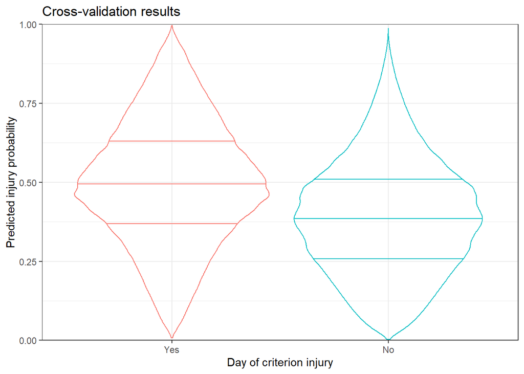

```r
cv_roc$obs <- factor(cv_roc$obs, levels = c("Yes", "No"))

ggplot(cv_roc, aes(x=obs, y=prob_yes, color = obs)) + geom_violin(fill=NA, draw_quantiles = c(0.25, 0.5, 0.75))  + ggtitle("Cross-validation results") + xlab("Day of criterion injury") + ylab("Predicted injury probability") +ggplot_theme+ theme(legend.position ="none") +scale_y_continuous(limits = c(0,1),expand = c(0,0))
```

### Feature importance

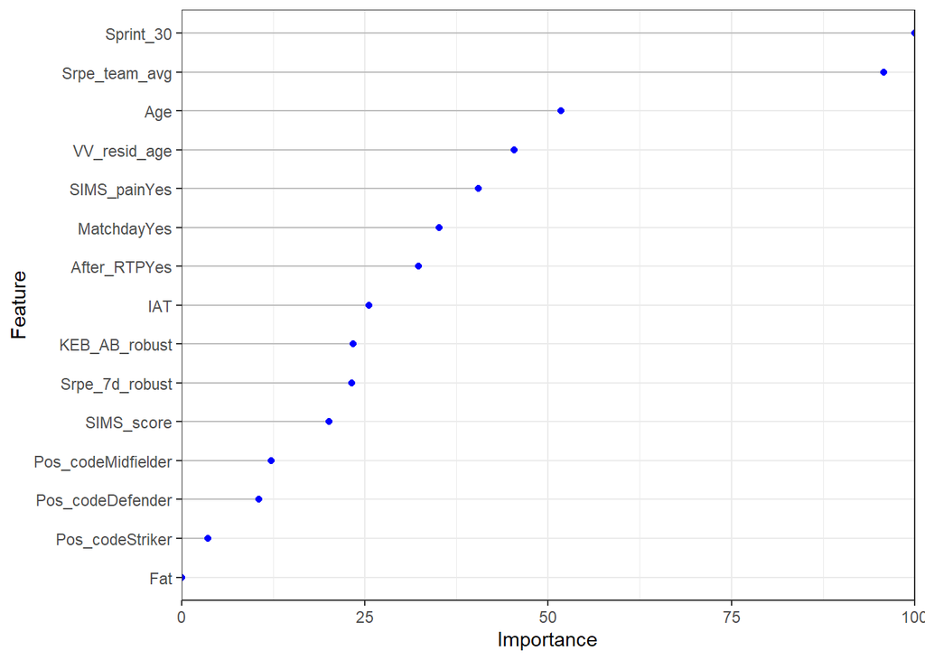

```r
plot_varimp<-function(model){
  plot_data<-varImp(model)$importance%>%rownames_to_column("Feature")%>%dplyr::rename(Importance=Overall)
  plot_data$Feature<-factor(plot_data$Feature,levels = plot_data$Feature[order(plot_data$Importance)] ,ordered = T)
  result<-ggplot(plot_data,aes(x=Importance,y=Feature)) +geom_segment( aes(x=0, xend=Importance, y=Feature, yend=Feature), color="grey") +
  geom_point( color="blue") +ggplot_theme+scale_x_continuous(expand = c(0,0))
  return (result)
}

plot_varimp(gbm_tree_auto)
```

### Get testset predictions

```r
# Apply to test set
Predicted_1 <- predict(gbm_tree_auto, newdata=data_test)

# View predictions for the test set
Predicted_1b <- data.frame(Predicted_1)

# Merge with testset
data_test_plus <- cbind(data_test, Predicted_1b)
data_test_plus$Predicted_1 <- factor(data_test_plus$Predicted_1, levels = c("No", "Yes"))

# Check confusion matrix
table(data_test_plus$Crit, data_test_plus$Predicted_1)
```

```
##
##         No  Yes
##   No  3186 1357
##   Yes    6    5
```

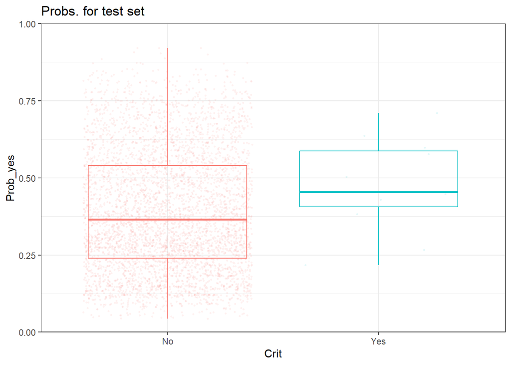

```r
# Get probabilities
Predicted_1p <- predict(gbm_tree_auto, newdata=data_test, type = "prob")
colnames(Predicted_1p) <- c("Prob_no", "Prob_yes")

# Merge
data_test_plus <- cbind(data_test_plus, Predicted_1p)
data_test_plus$Predicted <- factor(data_test_plus$Predicted, levels = c("No", "Yes"))

# Plot
ggplot(data_test_plus, aes(x=Crit, y=Prob_yes, color = Crit))+ geom_jitter(alpha=0.1,size=0.6,shape=16)+ geom_boxplot(outlier.shape = NA,fill=NA)   + ggtitle("Probs. for test set")+guides(color="none")+ggplot_theme+scale_y_continuous(expand=c(0,0),limits = c(0,1))
```

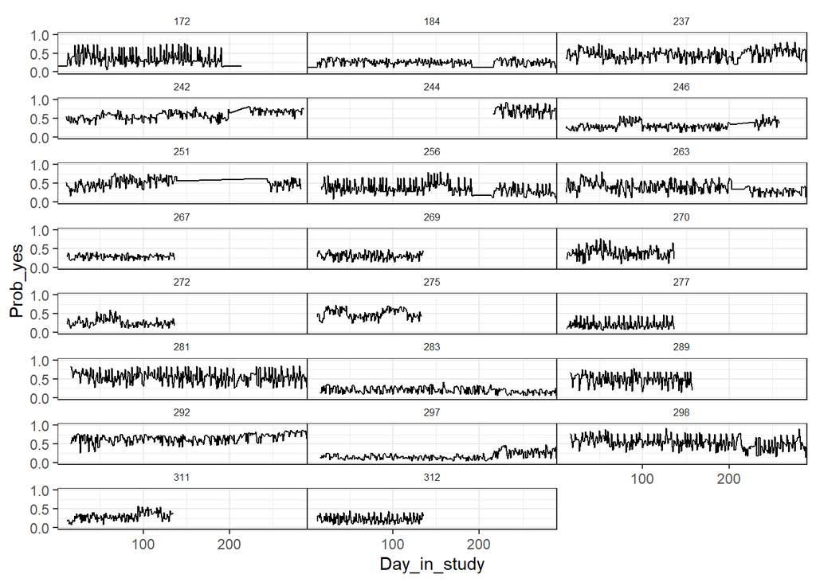

```r
ggplot(data_test_plus, aes(x=Day_in_study, y=Prob_yes) ) + geom_line() +facet_wrap(~ID,ncol = 3) +scale_y_continuous(limits = c(0,1),breaks = c(0,0.5,1))+ggplot_theme+theme(strip.background = element_blank(),strip.text = element_text(size=6),panel.spacing = unit(0, "lines"))+scale_x_continuous(expand=c(0,0))
```

## Testset performance

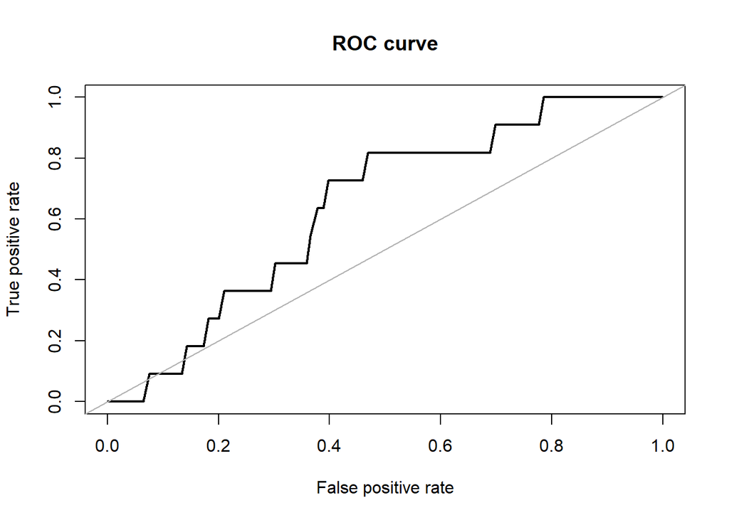

```r
# ROC curve test set
roc_test_1 <- roc.curve(response = data_test_plus$Crit, predicted = data_test_plus$Prob_yes)
```

```r
roc_test_1
```

```
## Area under the curve (AUC): 0.640
```

```r
roc_test_1$auc
```

```
## [1] 0.6404358
```

```r
## Brier score
data_test_plus$CritL <- data_test_plus$Crit == "Yes"
data_test_plus$CritL <- as.numeric(data_test_plus$CritL)

data_test_plus$Brier <- (data_test_plus$Prob_yes - data_test_plus$CritL)^2

Brier_score_test <- mean(data_test_plus$Brier)
Brier_score_test
```

```
## [1] 0.1918192
```

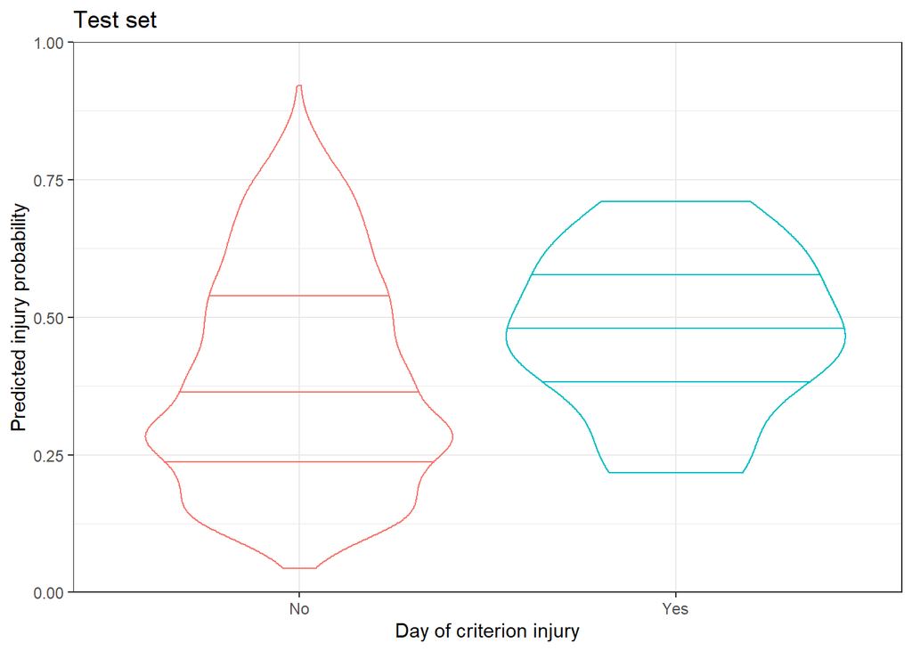

```r
ggplot(data_test_plus, aes(x=Crit, y=Prob_yes, color = Crit)) + geom_violin(fill=NA, draw_quantiles = c(0.25, 0.5, 0.75))  + ggtitle("Test set") + xlab("Day of criterion injury") + ylab("Predicted injury probability") +  ggplot_theme+ theme(legend.position ="none") +scale_y_continuous(limits = c(0,1),expand = c(0,0))
```

### Predictions on the training set

Predictions are made with the original (non-upsampled) training set

```r
# ROC curve training set
## Make predictions with initial (not upsampled) training set
Predicted_train_1 <- predict(gbm_tree_auto, newdata=data_training)

## View predictions for the training set
Predicted_train_1b <- data.frame(Predicted_train_1)

## Merge with trainingset
data_train_plus <- cbind(data_training, Predicted_train_1b)
data_train_plus$Predicted_train_1 <- factor(data_train_plus$Predicted_train_1, levels = c("No", "Yes"))

## Check confusion matrix
table(data_train_plus$Crit, data_train_plus$Predicted_train_1)
```

```
##
##          No   Yes
##   No  10276  2348
##   Yes    12    28
```

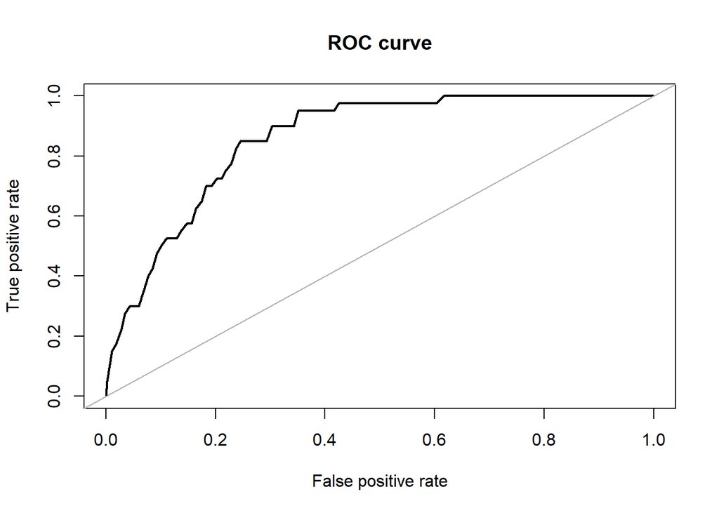

```r
## Get probabilities
Predicted_train_1p <- predict(gbm_tree_auto, newdata=data_training, type = "prob")
colnames(Predicted_train_1p) <- c("Prob_no", "Prob_yes")

## Merge
data_train_plus <- cbind(data_train_plus, Predicted_train_1p)

# ROC
roc_train_1 <- roc.curve(response = data_train_plus$Crit, predicted = data_train_plus$Prob_yes)
```

```r
roc_train_1
```

```
## Area under the curve (AUC): 0.857
```

```r
roc_train_1$auc
```

```
## [1] 0.8572253
```

```r
## Brier score
data_train_plus$CritL <- data_train_plus$Crit == "Yes"
data_train_plus$CritL <- as.numeric(data_train_plus$CritL)

data_train_plus$Brier <- (data_train_plus$Prob_yes - data_train_plus$CritL)^2

Brier_score_train <- mean(data_train_plus$Brier)
Brier_score_train
```

```
## [1] 0.1425197
```

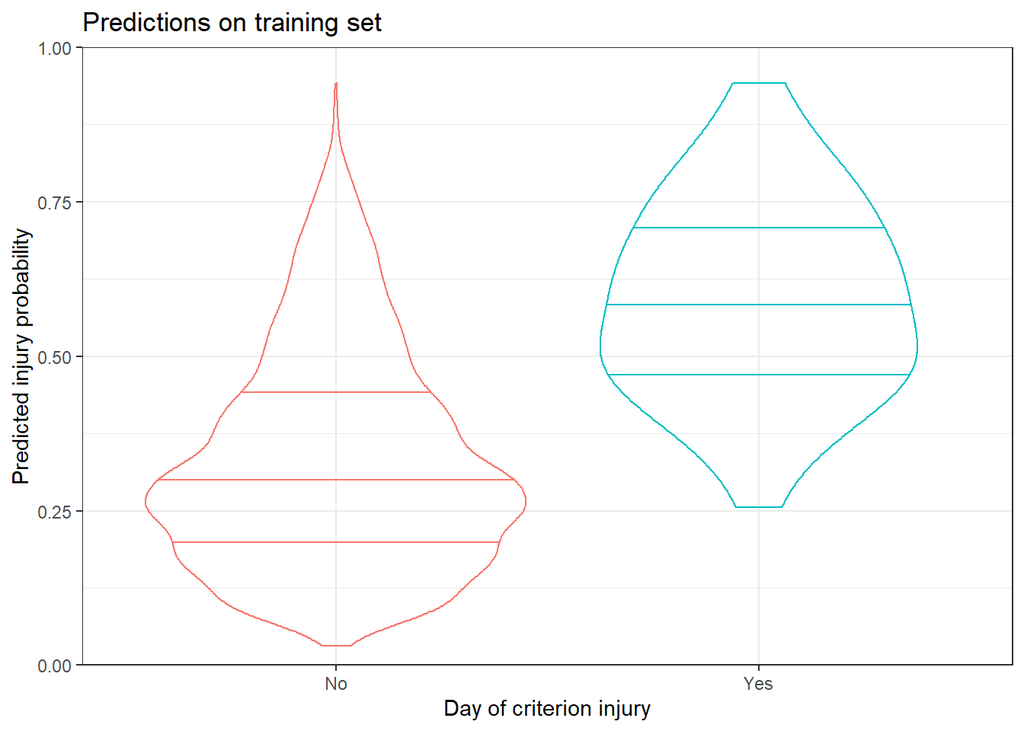

```r
ggplot(data_train_plus, aes(x=Crit, y=Prob_yes, color = Crit)) + geom_violin(fill=NA, draw_quantiles = c(0.25, 0.5, 0.75))  + ggtitle("Predictions on training set") + xlab("Day of criterion injury") + ylab("Predicted injury probability") +  ggplot_theme+ theme(legend.position ="none") +scale_y_continuous(limits = c(0,1),expand = c(0,0))
```

# Ancilary analysis 1: Round-Robin

The whole model fitting and evaluation process is repeated three times to probe the robustness of results and get comparable (test set) predictions for all players (e.g. for visualizing the time-course of probability predictions).

During the train-test split of each round, all players who were have previously been part of a test set are withheld and later added to the training set. The proportion of the split is adapted to get equal sized sets. Otherwise, the model fitting and evaluation process is the same as for the main analysis.

### Repeat split as round-robin

#### Get training and test sets 2/4

```r
# Preserve training and test set from first / main round
data_training_1 <- data_training
data_test_1 <- data_test

# Before filtering
data_x <- filter(data, ID %in% training_IDs) # original training set with full set of variables (including "Victim" to stratify the split)
data_y <- filter(data, !(ID %in% training_IDs)) # first round test set with full set of variables

# Get set of "unique" IDs never used for testing
data_unique_x <- distinct(data_x, ID, .keep_all = TRUE)

#Get IDs to split previous training set (never used for testing)
tr_prop = 0.66    # proportion of first training set to use for new split (equals ~ 0.75 from original)

training_set_2 = ddply(data_unique_x, .(Victim), function(., seed) { set.seed(seed); .[sample(1:nrow(.), trunc(nrow(.) * tr_prop)), ] }, seed = 5)

training_IDs_2 <- as.vector(training_set_2$ID)

# Use vector with training IDs to split data not previously used for testing
data_training_x <- filter(data_x, ID %in% training_IDs_2) # data / players never used for testing (including round 2)
data_test_2 <- filter(data_x, !(ID%in% training_IDs_2))

# Ad previous round test set to current training set
data_training_2 <- rbind(data_y, data_training_x)
```

#### Get training and test sets 3/4

```r
# Before filtering
data_x <- data_training_x # data not previously used for testing is data_training_x
data_y <- rbind(data_test_1, data_test_2) # data previously used for testing

# Get set of "unique" IDs never used for testing
data_unique_x <- distinct(data_x, ID, .keep_all = TRUE)

#Get IDs to split previous training set ("never used for testing)
tr_prop = 0.5    # proportion to use for new split (equals ~ 0.75 from original)

training_set_3 = ddply(data_unique_x, .(Victim), function(., seed) { set.seed(seed); .[sample(1:nrow(.), trunc(nrow(.) * tr_prop)), ] }, seed = 5)

training_IDs_3 <- as.vector(training_set_3$ID)

# Use vector with training IDs to split data not previously used for testing
data_training_x <- filter(data_x, ID %in% training_IDs_3) # data / players never used for testing
data_test_3 <- filter(data_x, !(ID%in% training_IDs_3))

# Ad previous test sets to current training set
data_training_3 <- rbind(data_y, data_training_x)
```

#### Get training and test sets 4/4

```r
# data not previously used for testing is data_training_x
data_y <- rbind(data_test_1, data_test_2, data_test_3) # data previously used for testing

# rename (no further split required)
data_training_4 <- data_y
data_test_4 <- data_training_x #last quarter never used for testing before
```

#### Check

```r
table(data_training_2$Victim)
```

```
##
##   No  Yes
## 6576 6227
```

```r
table(data_test_2$Victim)
```

```
##
##   No  Yes
## 2245 2170
```

```r
table(data_training_2$Crit)
```

```
##
##    No   Yes
## 12767    36
```

```r
table(data_training_3$Victim)
```

```
##
##   No  Yes
## 6711 6376
```

```r
table(data_test_3$Victim)
```

```
##
##   No  Yes
## 2110 2021
```

```r
table(data_training_3$Crit)
```

```
##
##    No   Yes
## 13048    39
```

```r
table(data_training_4$Victim)
```

```
##
##   No  Yes
## 6704 6396
```

```r
table(data_test_4$Victim)
```

```
##
##   No  Yes
## 2117 2001
```

```r
table(data_training_4$Crit)
```

```
##
##    No   Yes
## 13062    38
```

#### Subset secondary training sets

```r
data_training_2 <- subset(data_training_2, select = subset)
data_training_3 <- subset(data_training_3, select = subset)
data_training_4 <- subset(data_training_4, select = subset)
```

### Upsampling secondary training sets

#### Upsampling 2/4

```r
# Upsampling with ROSE
data_training_2_rose <- ROSE(Crit ~ ., data = data_training_2, N = 50000, seed = 42)$data

# Generate cross-validation folds index and remove ID
CV_folds_2<-groupKFold(data_training_2_rose$ID, k = 65)
data_training_2_rose<-select(data_training_2_rose, !ID)

# Check
table(data_training_2_rose$Crit)
```

```
##
##    No   Yes
## 24951 25049
```

#### Upsampling 3/4

```r
#Upsampling with ROSE
data_training_3_rose <- ROSE(Crit ~ ., data = data_training_3, N = 50000, seed = 42)$data

# Generate cross-validation folds index and remove ID
CV_folds_3<-groupKFold(data_training_3_rose$ID, k = 66)
data_training_3_rose<-select(data_training_3_rose, !ID)

# Check
table(data_training_3_rose$Crit)
```

```
##
##    No   Yes
## 24951 25049
```

#### Upsampling 4/4

```r
#Upsampling with ROSE
data_training_4_rose <- ROSE(Crit ~ ., data = data_training_4, N = 50000, seed = 42)$data

# Generate cross-validation folds index and remove ID
CV_folds_4 <-groupKFold(data_training_4_rose$ID, k = 68)
data_training_4_rose<-select(data_training_4_rose, !ID)

# Check
table(data_training_4_rose$Crit)
```

```
##
##    No   Yes
## 24951 25049
```

### Fit gradient boosted models for secondary (upsampled) training sets

#### Fit gradient boosted model 2/4

```r
# Work with multiple threads (use half of the available ones)
cl <- makePSOCKcluster(ceiling(detectCores()/2))
registerDoParallel(cl)

# Set cross-validation parameters
trainctrl_2 <- trainControl(method = "repeatedcv", number = 65, repeats = 10, summaryFunction = twoClassSummary, classProbs = TRUE, savePredictions = TRUE, index = CV_folds_2)

# Train the model
set.seed(42)
gbm_tree_auto_2 <- train(Crit ~ ., data = data_training_2_rose, method = "gbm", metric = "ROC", trControl = trainctrl_2, verbose = FALSE, tuneGrid = gbmGrid)
# End concurrent section
stopCluster(cl)
registerDoSEQ()

# Show model
gbm_tree_auto_2
```

```
## Stochastic Gradient Boosting
##
## 50000 samples
##    13 predictor
##     2 classes: 'No', 'Yes'
##
## No pre-processing
## Resampling: Cross-Validated (65 fold, repeated 10 times)
## Summary of sample sizes: 47817, 49132, 49697, 49458, 46692, 46589, ...
## Resampling results across tuning parameters:
##
##   interaction.depth  n.trees  ROC        Sens       Spec
##   1                   25      0.5522108  0.6037765  0.3477387
##   1                   50      0.5906776  0.6571850  0.3992907
##   1                   75      0.6116185  0.6787416  0.4249299
```

[output cut: 36 more lines]

#### Fit gradient boosted model 3/4

```r
# Work with multiple threads (use half of the available ones)
cl <- makePSOCKcluster(ceiling(detectCores()/2))
registerDoParallel(cl)

# Set cross-validation parameters
trainctrl_3 <- trainControl(method = "repeatedcv", number = 66, repeats = 10, summaryFunction = twoClassSummary, classProbs = TRUE, savePredictions = TRUE, index = CV_folds_3)

# Train the model
set.seed(42)
gbm_tree_auto_3 <- train(Crit ~ ., data = data_training_3_rose, method = "gbm", metric = "ROC", trControl = trainctrl_3, verbose = FALSE, tuneGrid = gbmGrid)
# End concurrent section
stopCluster(cl)
registerDoSEQ()

# Show model
gbm_tree_auto_3
```

```
## Stochastic Gradient Boosting
##
## 50000 samples
##    13 predictor
##     2 classes: 'No', 'Yes'
##
## No pre-processing
## Resampling: Cross-Validated (66 fold, repeated 10 times)
## Summary of sample sizes: 48815, 49145, 49485, 49554, 48938, 48830, ...
## Resampling results across tuning parameters:
##
##   interaction.depth  n.trees  ROC        Sens       Spec
##   1                   25      0.6128322  0.6177224  0.5062532
##   1                   50      0.6314937  0.6602541  0.5125096
##   1                   75      0.6326082  0.6616171  0.5050117
```

[output cut: 36 more lines]

#### Fit gradient boosted model 4/4

```r
# Work with multiple threads (use half of the available ones)
cl <- makePSOCKcluster(ceiling(detectCores()/2))
registerDoParallel(cl)

# Set cross-validation parameters
trainctrl_4 <- trainControl(method = "repeatedcv", number = 68, repeats = 10, summaryFunction = twoClassSummary, classProbs = TRUE, savePredictions = TRUE, index = CV_folds_4)

# Train the model
set.seed(42)
gbm_tree_auto_4 <- train(Crit ~ ., data = data_training_4_rose, method = "gbm", metric = "ROC", trControl = trainctrl_4, verbose = FALSE, tuneGrid = gbmGrid)
# End concurrent section
stopCluster(cl)
registerDoSEQ()

# Show model
gbm_tree_auto_4
```

```
## Stochastic Gradient Boosting
##
## 50000 samples
##    13 predictor
##     2 classes: 'No', 'Yes'
##
## No pre-processing
## Resampling: Cross-Validated (68 fold, repeated 10 times)
## Summary of sample sizes: 48802, 49168, 48657, 49709, 49518, 49415, ...
## Resampling results across tuning parameters:
##
##   interaction.depth  n.trees  ROC        Sens       Spec
##   1                   25      0.6399631  0.7087029  0.4481432
##   1                   50      0.6474752  0.6852834  0.4775776
##   1                   75      0.6422332  0.6696329  0.4967191
```

[output cut: 36 more lines]

### Cross-validation results of secondary models

#### Cross-validation results 2/4

```r
# Confusion matrix
confusionMatrix(
  gbm_tree_auto_2,
  norm = "overall",
  dnn = c("Prediction", "Crit")
)
```

```
## Cross-Validated (65 fold, repeated 10 times) Confusion Matrix
##
## (entries are percentual average cell counts across resamples)
##
##           Crit
## Prediction   No  Yes
##        No  33.6 25.7
##        Yes 16.3 24.4
##
##  Accuracy (average) : 0.5803
```

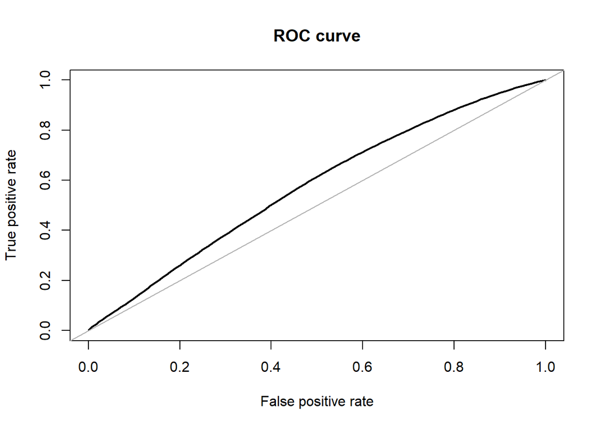

```r
# Extract from fit object
predicted <- as.data.frame(gbm_tree_auto_2$pred$pred)
observed <- as.data.frame(gbm_tree_auto_2$pred$obs)
prob_no <- as.data.frame(gbm_tree_auto_2$pred$No)
prob_yes <- as.data.frame(gbm_tree_auto_2$pred$Yes)

# ROC curve and AUC
cv_roc_2 <- cbind(predicted, observed, prob_no, prob_yes)
names(cv_roc_2) <- c("pred", "obs", "prob_no", "prob_yes")


cv_roc_2$obs_i <- cv_roc_2$obs == "Yes"

roc_2_cv <- roc.curve(response = cv_roc_2$obs_i, predicted = cv_roc_2$prob_yes)
```

```r
roc_2_cv
```

```
## Area under the curve (AUC): 0.574
```

```r
roc_2_cv$auc
```

```
## [1] 0.5744557
```

```r
# Brier score
cv_roc_2$obs_i <- as.numeric(cv_roc_2$obs_i)

cv_roc_2$Brier <- (cv_roc_2$prob_yes - cv_roc_2$obs_i)^2

Brier_score_cv_2 <- mean(cv_roc_2$Brier)
Brier_score_cv_2
```

```
## [1] 0.2646607
```

#### Cross-validation results 3/4

```r
# Confusion matrix
confusionMatrix(
  gbm_tree_auto_3,
  norm = "overall",
  dnn = c("Prediction", "Crit")
)
```

```
## Cross-Validated (66 fold, repeated 10 times) Confusion Matrix
##
## (entries are percentual average cell counts across resamples)
##
##           Crit
## Prediction   No  Yes
##        No  34.5 22.4
##        Yes 15.4 27.7
##
##  Accuracy (average) : 0.622
```

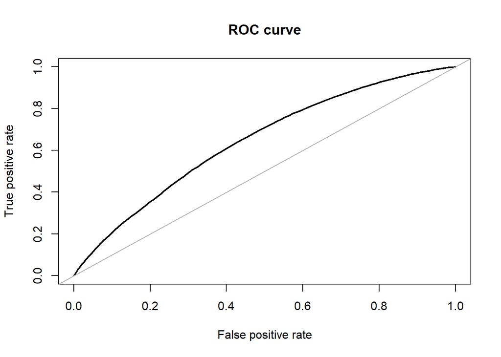

```r
# Extract from fit object
predicted <- as.data.frame(gbm_tree_auto_3$pred$pred)
observed <- as.data.frame(gbm_tree_auto_3$pred$obs)
prob_no <- as.data.frame(gbm_tree_auto_3$pred$No)
prob_yes <- as.data.frame(gbm_tree_auto_3$pred$Yes)

# ROC curve and AUC
cv_roc_3 <- cbind(predicted, observed, prob_no, prob_yes)
names(cv_roc_3) <- c("pred", "obs", "prob_no", "prob_yes")


cv_roc_3$obs_i <-   cv_roc_3$obs == "Yes"


roc_3_cv <- roc.curve(response = cv_roc_3$obs_i, predicted = cv_roc_3$prob_yes)
```

```r
roc_3_cv
```

```
## Area under the curve (AUC): 0.645
```

```r
roc_3_cv$auc
```

```
## [1] 0.6453433
```

```r
# Brier score
cv_roc_3$obs_i <- as.numeric(cv_roc_3$obs_i)

cv_roc_3$Brier <- (cv_roc_3$prob_yes - cv_roc_3$obs_i)^2

Brier_score_cv_3 <- mean(cv_roc_3$Brier)
Brier_score_cv_3
```

```
## [1] 0.2406056
```

#### Cross-validation results 4/4

```r
# Confusion matrix
confusionMatrix(
  gbm_tree_auto_4,
  norm = "overall",
  dnn = c("Prediction", "Crit")
)
```

```
## Cross-Validated (68 fold, repeated 10 times) Confusion Matrix
##
## (entries are percentual average cell counts across resamples)
##
##           Crit
## Prediction   No  Yes
##        No  35.1 25.5
##        Yes 14.8 24.6
##
##  Accuracy (average) : 0.597
```

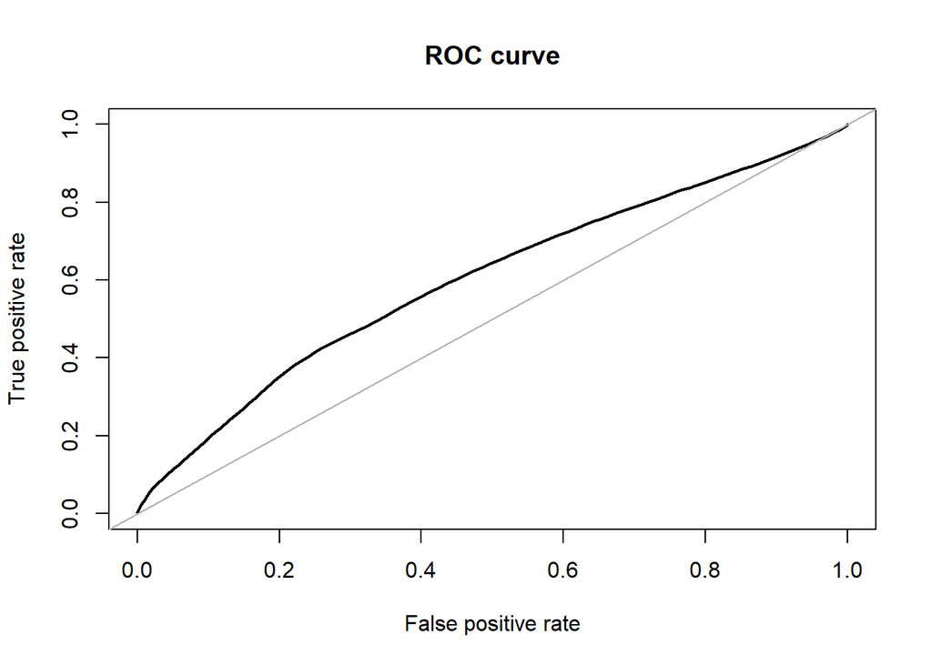

```r
# Extract from fit object
predicted <- as.data.frame(gbm_tree_auto_4$pred$pred)
observed <- as.data.frame(gbm_tree_auto_4$pred$obs)
prob_no <- as.data.frame(gbm_tree_auto_4$pred$No)
prob_yes <- as.data.frame(gbm_tree_auto_4$pred$Yes)

# ROC curve and AUC
cv_roc_4 <- cbind(predicted, observed, prob_no, prob_yes)
names(cv_roc_4) <- c("pred", "obs", "prob_no", "prob_yes")


cv_roc_4$obs_i <-  cv_roc_4$obs == "Yes"

roc_4_cv <- roc.curve(response = cv_roc_4$obs_i, predicted = cv_roc_4$prob_yes)
```

```r
roc_4_cv
```

```
## Area under the curve (AUC): 0.600
```

```r
roc_4_cv$auc
```

```
## [1] 0.6002445
```

```r
# Brier score
cv_roc_4$obs_i <- as.numeric(cv_roc_4$obs_i)

cv_roc_4$Brier <- (cv_roc_4$prob_yes - cv_roc_4$obs_i)^2

Brier_score_cv_4 <- mean(cv_roc_4$Brier)
Brier_score_cv_4
```

```
## [1] 0.2594562
```

### Test set performance of secondary models

#### Apply trained model to testset 2/4

```r
# Apply to test set
Predicted_2 <- predict(gbm_tree_auto_2, newdata=data_test_2)

# View predictions for the test set
Predicted_2b <- data.frame(Predicted_2)

# Merge with testset
data_test_plus_2 <- cbind(data_test_2, Predicted_2b)

# Check confusion matrix
table(data_test_plus_2$Crit, data_test_plus_2$Predicted_2)
```

```
##
##         No  Yes
##   No  3140 1260
##   Yes    9    6
```

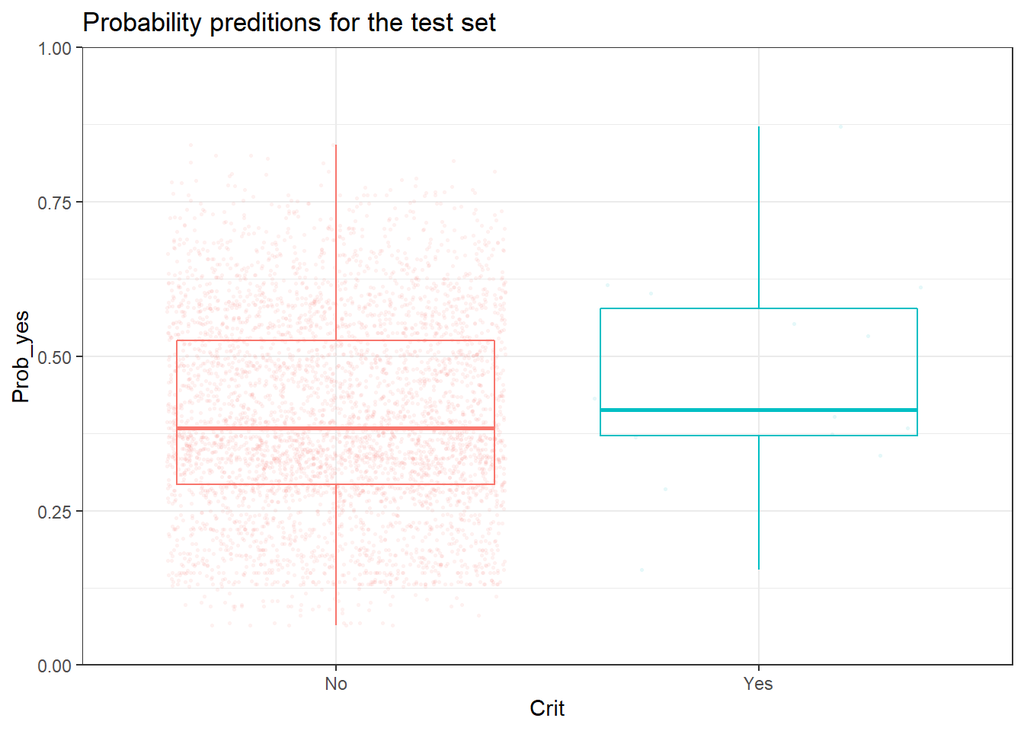

```r
## Get probabilities
Predicted_2p <- predict(gbm_tree_auto_2, newdata=data_test_2, type = "prob")
colnames(Predicted_2p) <- c("Prob_no", "Prob_yes")

# Merge
data_test_plus_2 <- cbind(data_test_plus_2, Predicted_2p)
data_test_plus_2$Predicted <- factor(data_test_plus_2$Predicted_2, levels = c("No", "Yes"))

# Plot
ggplot(data_test_plus_2, aes(x=Crit, y=Prob_yes, color = Crit))+ geom_jitter(alpha=0.1,size=0.6,shape=16)+ geom_boxplot(outlier.shape = NA,fill=NA)   +guides(color="none")+ggplot_theme+scale_y_continuous(expand=c(0,0),limits = c(0,1))  + ggtitle("Probability preditions for the test set")
```

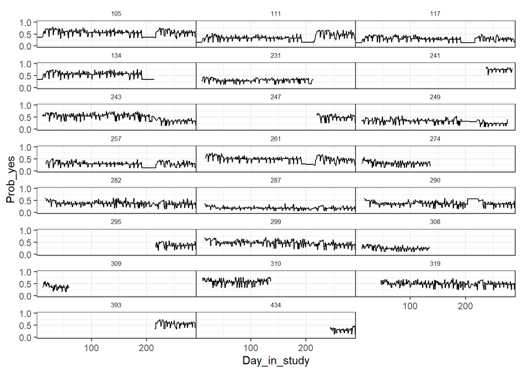

```r
ggplot(data_test_plus_2, aes(x=Day_in_study, y=Prob_yes) )+ geom_line() +facet_wrap(~ID,ncol = 3) +scale_y_continuous(limits = c(0,1),breaks = c(0,0.5,1))+ggplot_theme+theme(strip.background = element_blank(),strip.text = element_text(size=6),panel.spacing = unit(0, "lines"))+scale_x_continuous(expand=c(0,0))
```

##### Get testset performance 2/4

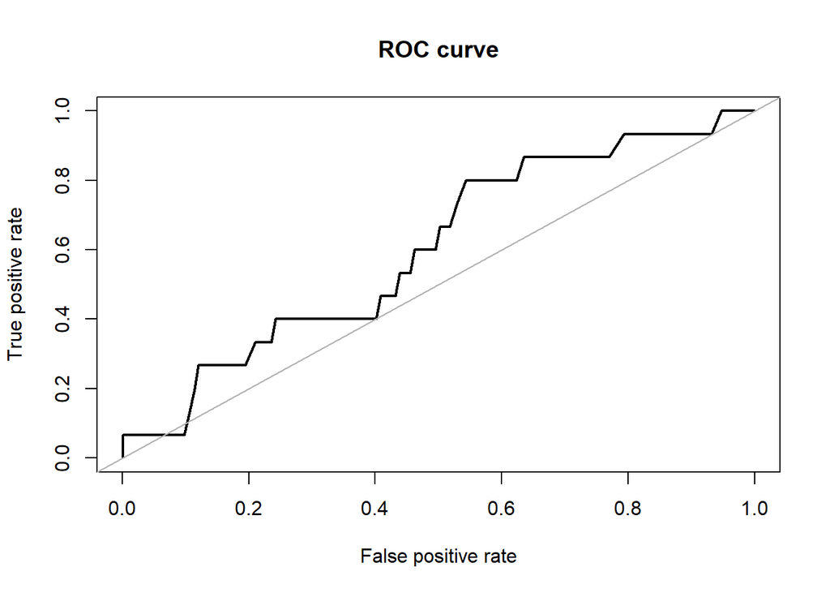

```r
# ROC curve and AUC
roc_test_2 <- roc.curve(response = data_test_plus_2$Crit, predicted = data_test_plus_2$Prob_yes)
```

```r
roc_test_2
```

```
## Area under the curve (AUC): 0.601
```

```r
roc_test_2$auc
```

```
## [1] 0.6014167
```

```r
## Brier score
data_test_plus_2$CritL <- data_test_plus_2$Crit == "Yes"
data_test_plus_2$CritL <- as.numeric(data_test_plus_2$CritL)

data_test_plus_2$Brier <- (data_test_plus_2$Prob_yes - data_test_plus_2$CritL)^2

Brier_score_test_2 <- mean(data_test_plus_2$Brier)
Brier_score_test_2
```

```
## [1] 0.1879722
```

##### Get feature importance 2/4

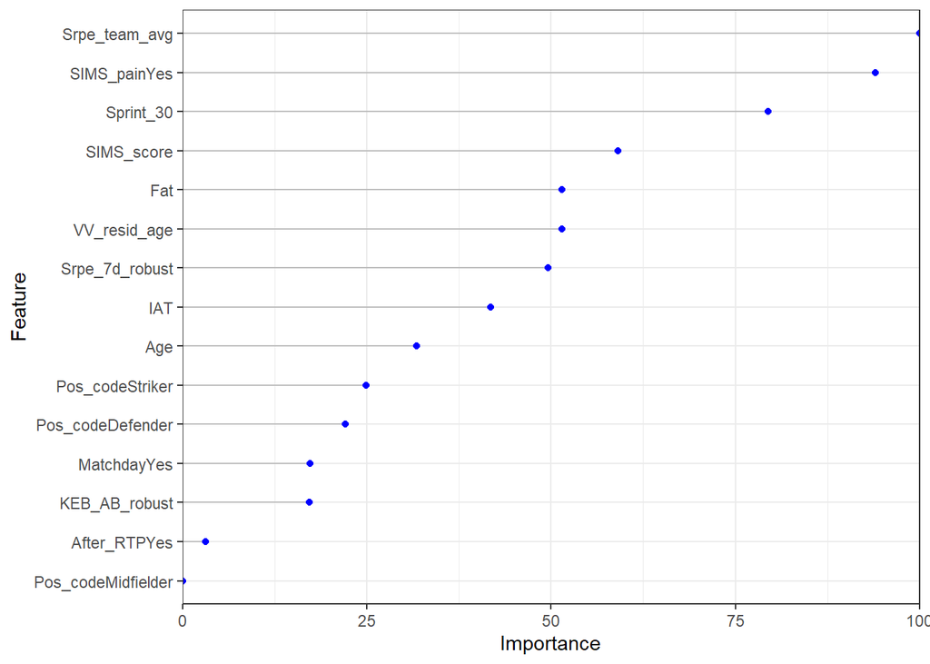

```r
plot_varimp(gbm_tree_auto_2)
```

#### Apply trained model to testset 3/4

```r
# Apply to test set
Predicted_3 <- predict(gbm_tree_auto_3, newdata=data_test_3)

# View predictions for the test set
Predicted_3b <- data.frame(Predicted_3)

# Merge with testset
data_test_plus_3 <- cbind(data_test_3, Predicted_3b)

# Check confusion matrix
table(data_test_plus_3$Crit, data_test_plus_3$Predicted_3)
```

```
##
##         No  Yes
##   No  3213  906
##   Yes    8    4
```

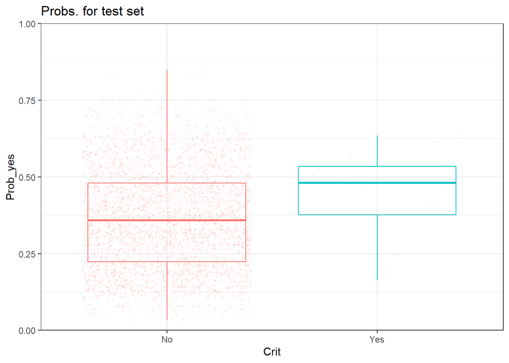

```r
## Get probabilities
Predicted_3p <- predict(gbm_tree_auto_3, newdata=data_test_3, type = "prob")
colnames(Predicted_3p) <- c("Prob_no", "Prob_yes")

# Merge
data_test_plus_3 <- cbind(data_test_plus_3, Predicted_3p)
data_test_plus_3$Predicted <- factor(data_test_plus_3$Predicted_3, levels = c("No", "Yes"))

# Plot
ggplot(data_test_plus_3, aes(x=Crit, y=Prob_yes, color = Crit))+ geom_jitter(alpha=0.1,size=0.6,shape=16)+ geom_boxplot(outlier.shape = NA,fill=NA)   +guides(color="none")+ggplot_theme+scale_y_continuous(expand=c(0,0),limits = c(0,1))  + ggtitle("Probs. for test set")
```

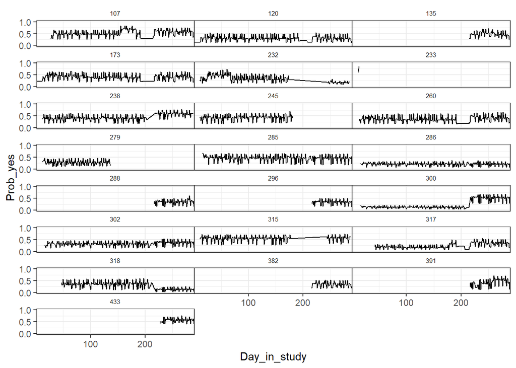

```r
ggplot(data_test_plus_3, aes(x=Day_in_study, y=Prob_yes) ) + geom_line() +facet_wrap(~ID,ncol = 3) +scale_y_continuous(limits = c(0,1),breaks = c(0,0.5,1))+ggplot_theme+theme(strip.background = element_blank(),strip.text = element_text(size=6),panel.spacing = unit(0, "lines"))+scale_x_continuous(expand=c(0,0))
```

##### Get testset performance 3/4

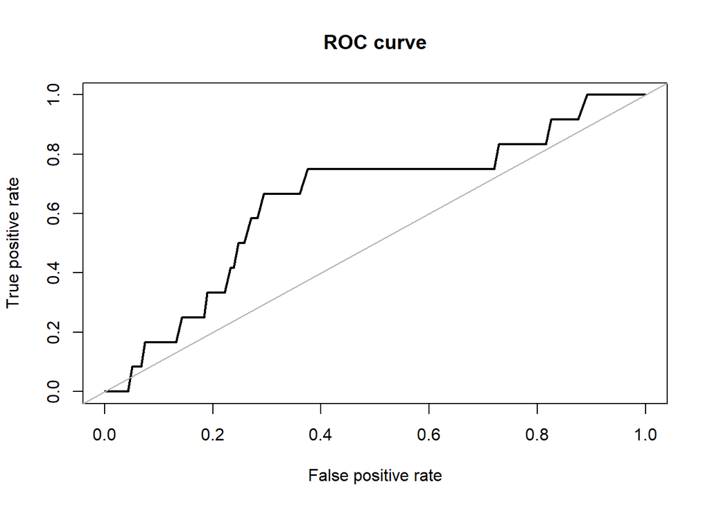

```r
# ROC curve and AUC
roc_test_3 <- roc.curve(response = data_test_plus_3$Crit, predicted = data_test_plus_3$Prob_yes)
```

```r
roc_test_3
```

```
## Area under the curve (AUC): 0.645
```

```r
roc_test_3$auc
```

```
## [1] 0.6449077
```

```r
# Brier score
data_test_plus_3$CritL <- data_test_plus_3$Crit == "Yes"
data_test_plus_3$CritL <- as.numeric(data_test_plus_3$CritL)

data_test_plus_3$Brier <- (data_test_plus_3$Prob_yes - data_test_plus_3$CritL)^2

Brier_score_test_3 <- mean(data_test_plus_3$Brier)
Brier_score_test_3
```

```
## [1] 0.1585457
```

##### Feature importance 3/4

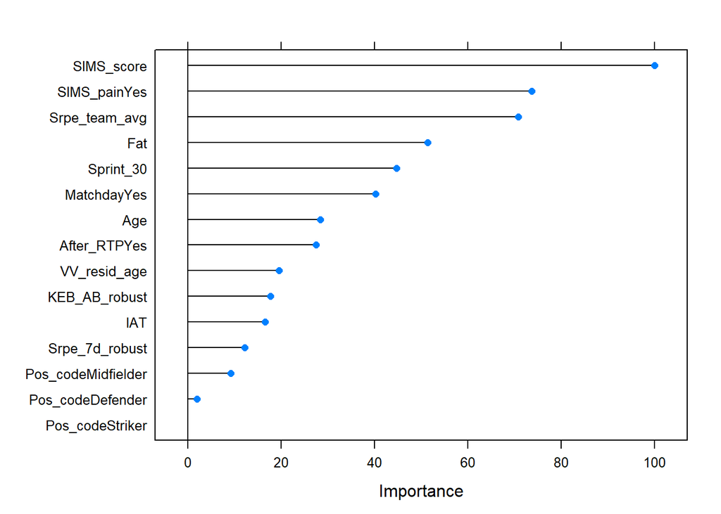

```r
plot(varImp(gbm_tree_auto_3))
```

#### Apply trained model to testset 4/4

```r
# Apply to test set
Predicted_4 <- predict(gbm_tree_auto_4, newdata=data_test_4)

# View predictions for the test set
Predicted_4b <- data.frame(Predicted_4)

# Merge with testset
data_test_plus_4 <- cbind(data_test_4, Predicted_4b)

# Check confusion matrix
table(data_test_plus_4$Crit, data_test_plus_4$Predicted_4)
```

```
##
##         No  Yes
##   No  3229  876
##   Yes   10    3
```

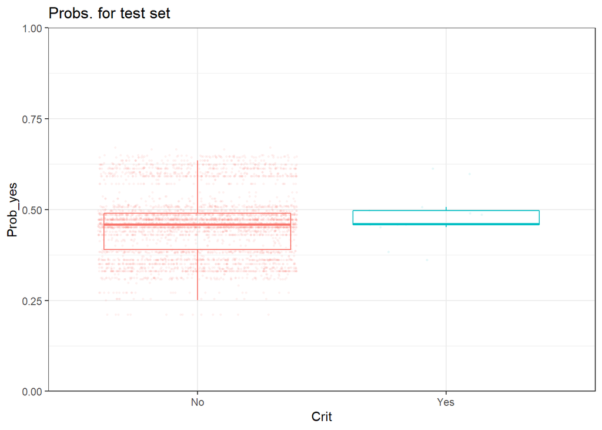

```r
## Get probabilities

Predicted_4p <- predict(gbm_tree_auto_4, newdata=data_test_4, type = "prob")
colnames(Predicted_4p) <- c("Prob_no", "Prob_yes")

# Merge
data_test_plus_4 <- cbind(data_test_plus_4, Predicted_4p)
data_test_plus_4$Predicted <- factor(data_test_plus_4$Predicted_4, levels = c("No", "Yes"))

# Plot
ggplot(data_test_plus_4, aes(x=Crit, y=Prob_yes, color = Crit))+ geom_jitter(alpha=0.1,size=0.6,shape=16)+ geom_boxplot(outlier.shape = NA,fill=NA)   +guides(color="none")+ggplot_theme+scale_y_continuous(expand=c(0,0),limits = c(0,1))  + ggtitle("Probs. for test set")
```

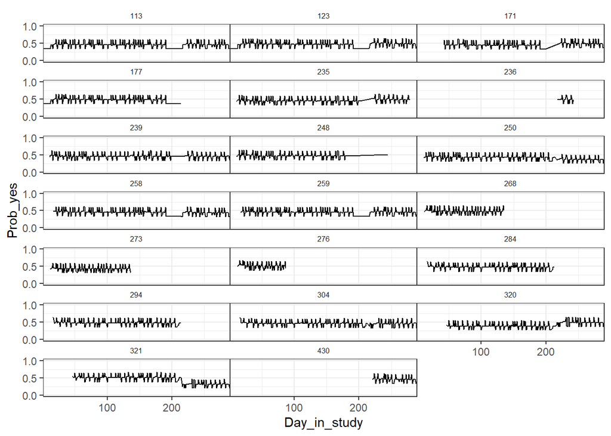

```r
ggplot(data_test_plus_4, aes(x=Day_in_study, y=Prob_yes) )+ geom_line() +facet_wrap(~ID,ncol = 3) +scale_y_continuous(limits = c(0,1),breaks = c(0,0.5,1))+ggplot_theme+theme(strip.background = element_blank(),strip.text = element_text(size=6),panel.spacing = unit(0, "lines"))+scale_x_continuous(expand=c(0,0))
```

##### Get testset performance 4/4

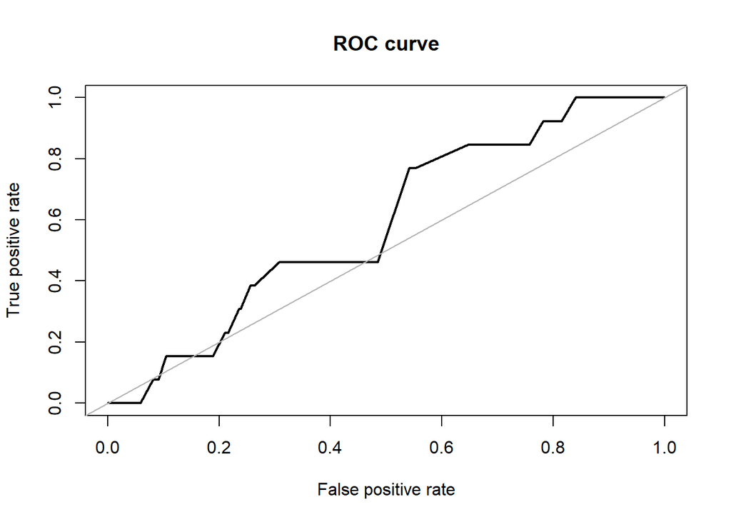

```r
# ROC curve and AUC
roc_test_4 <- roc.curve(response = data_test_plus_4$Crit, predicted = data_test_plus_4$Prob_yes)
```

```r
roc_test_4
```

```
## Area under the curve (AUC): 0.587
```

```r
roc_test_4$auc
```

```
## [1] 0.5867235
```

```r
# Brier score
data_test_plus_4$CritL <- data_test_plus_4$Crit == "Yes"
data_test_plus_4$CritL <- as.numeric(data_test_plus_4$CritL)

data_test_plus_4$Brier <- (data_test_plus_4$Prob_yes - data_test_plus_4$CritL)^2

Brier_score_test_4 <- mean(data_test_plus_4$Brier)
Brier_score_test_4
```

```
## [1] 0.2174409
```

##### Feature importance 4/4

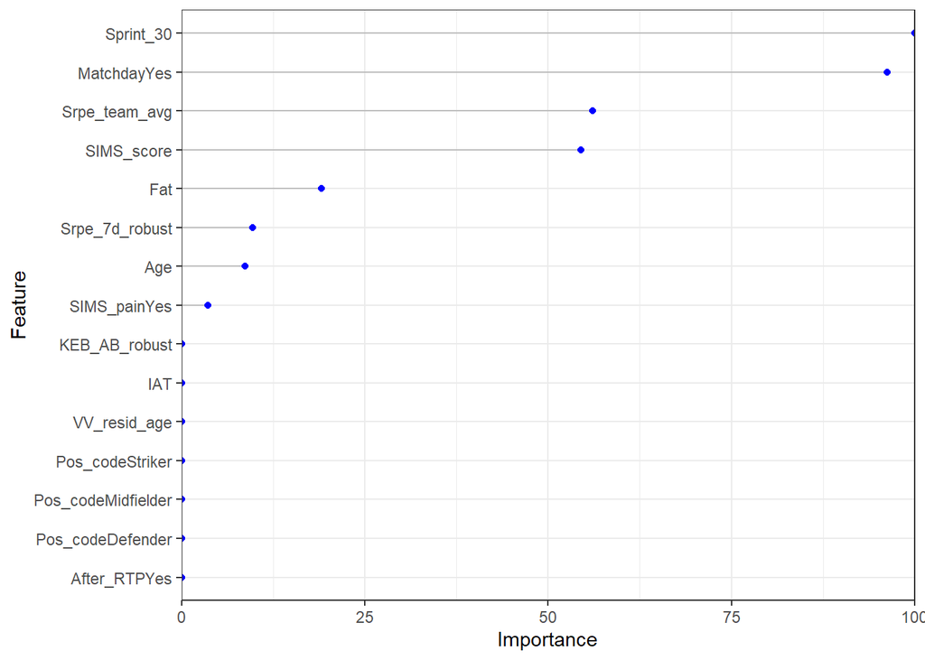

```r
plot_varimp(gbm_tree_auto_4)
```

### Summary of round-robin results

#### Timecourse of probability predictions

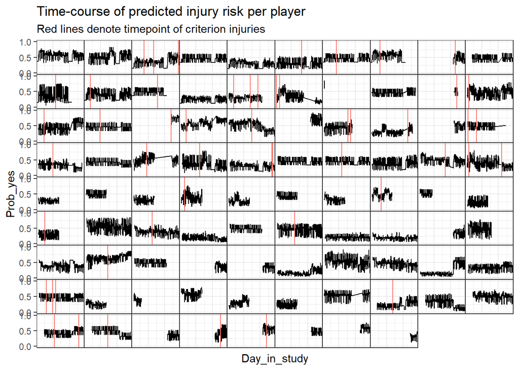

```r
# Assign variable for run
data_test_plus$Run <- 1
data_test_plus <- subset(data_test_plus,  select = -Predicted_1)
data_test_plus_2$Run <- 2
data_test_plus_2 <- subset(data_test_plus_2,  select = -Predicted_2)
data_test_plus_3$Run <- 3
data_test_plus_3 <- subset(data_test_plus_3,  select = -Predicted_3)
data_test_plus_4$Run <- 4
data_test_plus_4 <- subset(data_test_plus_4,  select = -Predicted_4)

# Merge
data_test_plus_all <- rbind(data_test_plus, data_test_plus_2, data_test_plus_3, data_test_plus_4)

# Adjust type for "Run"
data_test_plus_all$Run <- as.factor(data_test_plus_all$Run)

# Iday
data_test_plus_all$Iday <- case_when(
  data_test_plus_all$Crit == "Yes" ~ data_test_plus_all$Day_in_study
    )

data_test_plus_all$Iday <- as.integer(data_test_plus_all$Iday)

data_test_plus_all_grouped <- group_by(data_test_plus_all, ID)

# Plot
ggplot(data_test_plus_all, aes(x=Day_in_study, y=Prob_yes) ) +
  geom_line() +
  facet_wrap(~ID) +
  geom_vline(data = data_test_plus_all_grouped, aes(xintercept = Iday, color = "red")) +
  ggplot_theme+
  theme(axis.text.x=element_blank(),
        axis.ticks.x = element_blank(),
        legend.position = "none",
        strip.text.x = element_blank(),
        strip.background = element_blank(),
        panel.spacing = unit(0, "lines")
        ) +
  labs(title = "Time-course of predicted injury risk per player", subtitle = "Red lines denote timepoint of criterion injuries" )+
  scale_y_continuous(limits = c(0,1),breaks = c(0,0.5,1))+scale_x_continuous(expand=c(0,0))
```

##### Performance with pooled test set predicitons

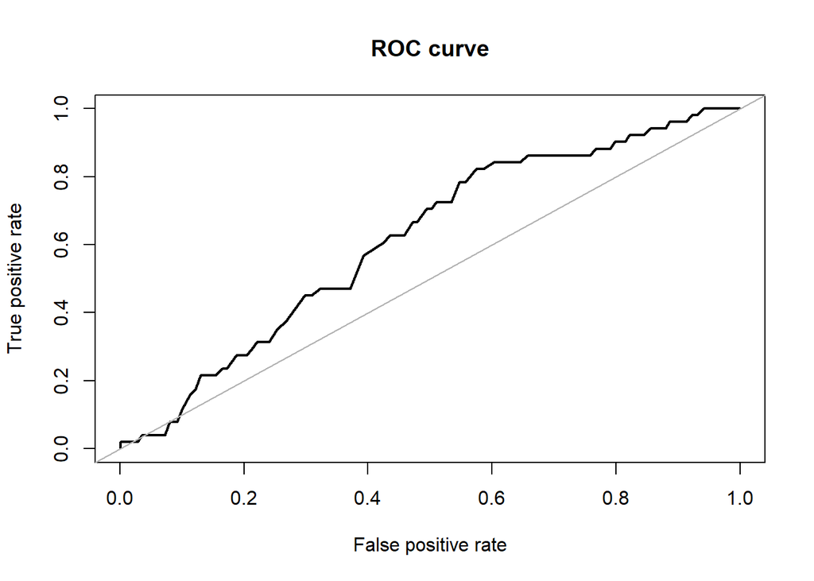

```r
# ROc curve and AUC
data_test_plus_all$Predicted <- factor(data_test_plus_all$Predicted, levels = c("No", "Yes"))
roc_test_1 <- roc.curve(response = data_test_plus_all$Crit, predicted = data_test_plus_all$Prob_yes)
```

```r
roc_test_1
```

```
## Area under the curve (AUC): 0.615
```

```r
roc_test_1$auc
```

```
## [1] 0.6151674
```

```r
## Brier score
data_test_plus_all$CritL <- case_when(data_test_plus_all$Crit == "No" ~ "0", TRUE ~ "1")
data_test_plus_all$CritL <- as.numeric(data_test_plus_all$CritL)

data_test_plus_all$Brier <- (data_test_plus_all$Prob_yes - data_test_plus_all$CritL)^2

Brier_score_test <- mean(data_test_plus_all$Brier)
Brier_score_test
```

```
## [1] 0.1889776
```

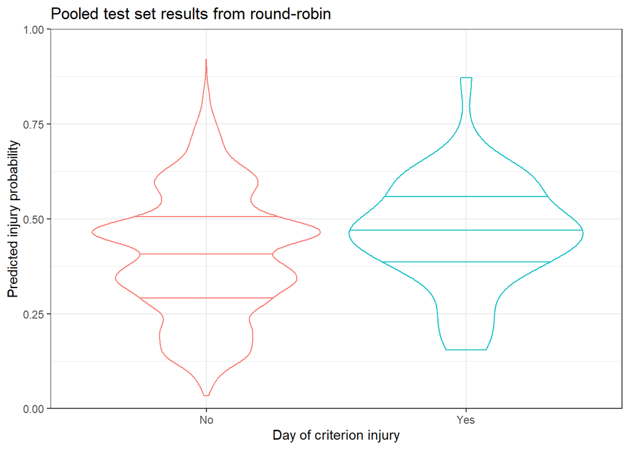

```r
# Plot
ggplot(data_test_plus_all, aes(x=Crit, y=Prob_yes, color = Crit)) + geom_violin(fill=NA, draw_quantiles = c(0.25, 0.5, 0.75))  + ggtitle("Pooled test set results from round-robin") + xlab("Day of criterion injury") + ylab("Predicted injury probability")  +ggplot_theme+ theme(legend.position ="none") +scale_y_continuous(limits = c(0,1),expand = c(0,0))
```

# Performance - the practical perspective

## Proportion needed to prevent - Predictions based on cross-validated model from full dataset

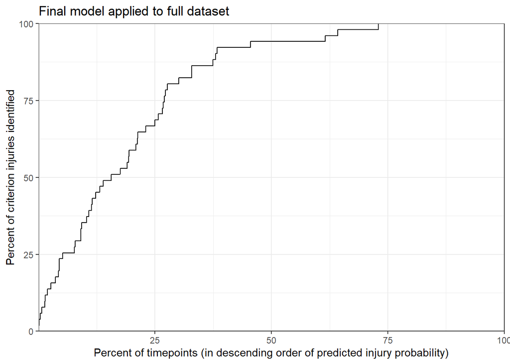

```r
# Make predictions with initial (not upsampled) training set
Predicted_full <- predict(gbm_tree_auto, newdata=data)

## View predictions
Predicted_fullb <- data.frame(Predicted_full)

## Merge with training set
data_full_plus <- cbind(data, Predicted_fullb)
data_full_plus$Predicted_full <- factor(data_full_plus$Predicted_full, levels = c("No", "Yes"))

## Get probabilities
Predicted_fullp <- predict(gbm_tree_auto, newdata=data, type = "prob")
colnames(Predicted_fullp) <- c("Prob_no", "Prob_yes")

## Merge
data_full_plus <- cbind(data_full_plus, Predicted_fullp)
data_full_plus$CritL <- data_full_plus$Crit == "Yes"
data_full_plus$CritL <- as.numeric(data_full_plus$CritL)

# Datapoints ordered by Prob_yes
data_full_plus_plot <- arrange(data_full_plus, desc(Prob_yes))
data_full_plus_plot$dp_ordered = rownames(data_full_plus_plot)
data_full_plus_plot$dp_rel <- as.numeric(data_full_plus_plot$dp_ordered)/max(as.numeric(data_full_plus_plot$dp_ordered))
data_full_plus_plot$ntile <- percent_rank(data_full_plus_plot$Prob_yes)
data_full_plus_plot$ntile <- 100-(data_full_plus_plot$ntile*100)
data_full_plus_plot$cumsum <- cumsum(data_full_plus_plot$CritL)
data_full_plus_plot$captured <- (data_full_plus_plot$cumsum/51)*100

# Plot
ggplot(data_full_plus_plot, aes(x=as.numeric(ntile), y=as.numeric(captured))) + geom_line() +ggplot_theme+ xlab("Percent of timepoints (in descending order of predicted injury probability)") + ylab("Percent of criterion injuries identified") + labs(title = "Final model applied to full dataset") +scale_x_continuous(expand = c(0,0))+scale_y_continuous(expand = c(0,0))
```

## “Proportion needed to prevent” in pooled test sets

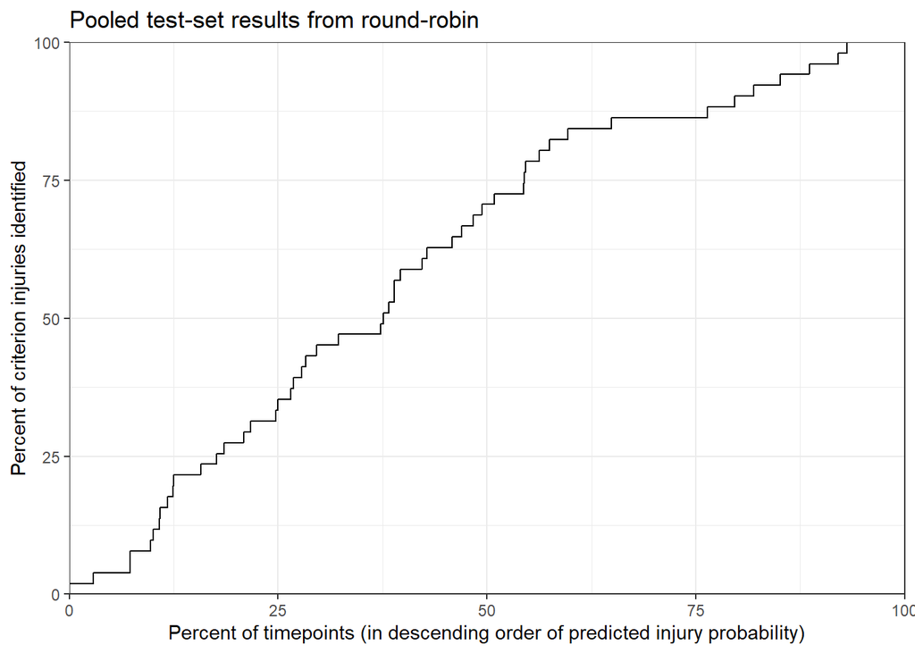

```r
# Datapoints ordered by prob_yes
data_test_plus_plot <- arrange(data_test_plus_all, desc(Prob_yes))
data_test_plus_plot$dp_ordered = rownames(data_test_plus_plot)
data_test_plus_plot$dp_rel <- as.numeric(data_test_plus_plot$dp_ordered)/max(as.numeric(data_test_plus_plot$dp_ordered))
data_test_plus_plot$ntile <- percent_rank(data_test_plus_plot$Prob_yes)
data_test_plus_plot$ntile <- 100-(data_test_plus_plot$ntile*100)
data_test_plus_plot$cumsum <- cumsum(data_test_plus_plot$CritL)
data_test_plus_plot$captured <- (data_test_plus_plot$cumsum/51)*100

# Plot
ggplot(data_test_plus_plot, aes(x=as.numeric(ntile), y=as.numeric(captured))) + geom_line() +ggplot_theme+ xlab("Percent of timepoints (in descending order of predicted injury probability)") + ylab("Percent of criterion injuries identified") + labs(title = "Pooled test-set results from round-robin") +scale_x_continuous(expand = c(0,0))+scale_y_continuous(expand = c(0,0))
```

# Ancillary analysis 2: Leaky folds

In Monitoring datasets, timepoints are nested within players. This hierarchical structure has to be considered when setting up cross-validation, specifically cross-validation folds must be constructed on the level of players - not datapoints. Otherwise leaking of information between folds will lead to a spurious increase in cross-validation performance metrics (which does not generalize to test set performance or future data). To demonstrate this point (which is not regularly addressed in previous work) we repeat the main analysis with the only difference that cross-validation is performed on the level of datapoints (as customary for datasets without hierarchical structure).

## Fit gradient-boosted model with “leaky folds”

```r
# Work with multiple threads (use half of the available ones)
cl <- makePSOCKcluster(ceiling(detectCores()/2))
registerDoParallel(cl)

trainctrl_leaky <- trainControl(method = "repeatedcv", number = 65, repeats = 10, summaryFunction = twoClassSummary, classProbs = TRUE, savePredictions = TRUE)  # no index argument (CV_folds generated in the upsampling step not used)!

gbmGrid <-    expand.grid(interaction.depth = 2^(0:3),
                          n.trees = (1:8)*25,
                          shrinkage = 0.1,
                          n.minobsinnode = 10)

set.seed(42)
gbm_tree_auto_leaky <- train(Crit ~ ., data = data_training_rose, method = "gbm", metric = "ROC", trControl = trainctrl_leaky, verbose = FALSE, tuneGrid = gbmGrid)

#End concurrent section
stopCluster(cl)
registerDoSEQ()

# Show model
gbm_tree_auto_leaky
```

```
## Stochastic Gradient Boosting
##
## 50000 samples
##    13 predictor
##     2 classes: 'No', 'Yes'
##
## No pre-processing
## Resampling: Cross-Validated (65 fold, repeated 10 times)
## Summary of sample sizes: 49230, 49230, 49230, 49231, 49231, 49231, ...
## Resampling results across tuning parameters:
##
##   interaction.depth  n.trees  ROC        Sens       Spec
##   1                   25      0.7312226  0.6894549  0.6621625
##   1                   50      0.7519814  0.7192978  0.6619282
##   1                   75      0.7621804  0.7233584  0.6696169
```

[output cut: 36 more lines]

### Get cross-validation performance metrics

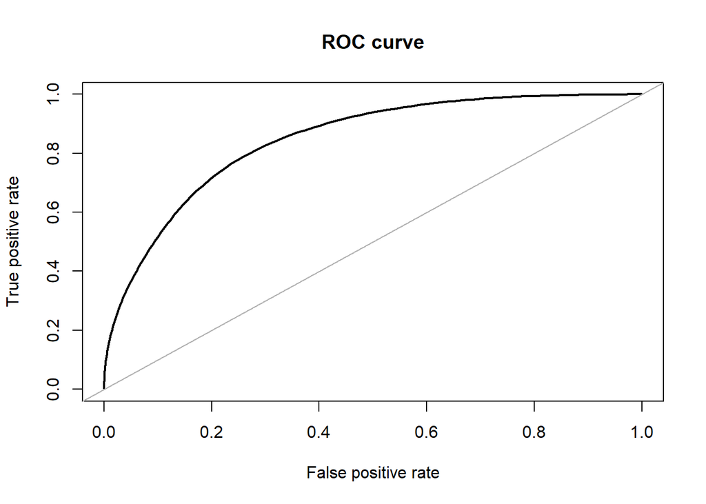

```r
# Extract from fit object
predicted <- as.data.frame(gbm_tree_auto_leaky$pred$pred)
observed <- as.data.frame(gbm_tree_auto_leaky$pred$obs)
prob_no <- as.data.frame(gbm_tree_auto_leaky$pred$No)
prob_yes <- as.data.frame(gbm_tree_auto_leaky$pred$Yes)

# ROC curve and AUC
cv_roc_leaky <- cbind(predicted, observed, prob_no, prob_yes)
names(cv_roc_leaky) <- c("pred", "obs", "prob_no", "prob_yes")


cv_roc_leaky$obs_i <- cv_roc_leaky$obs == "Yes"

roc_leaky <- roc.curve(response = cv_roc_leaky$obs_i, predicted = cv_roc_leaky$prob_yes)
```

```r
roc_leaky
```

```
## Area under the curve (AUC): 0.845
```

```r
roc_leaky$auc
```

```
## [1] 0.8448807
```

```r
# Brier score
cv_roc_leaky$obs_i <- as.numeric(cv_roc_leaky$obs_i)

cv_roc_leaky$Brier <- (cv_roc_leaky$prob_yes - cv_roc_leaky$obs_i)^2

Brier_score_cv_leaky <- mean(cv_roc_leaky$Brier)
Brier_score_cv_leaky
```

```
## [1] 0.1689697
```

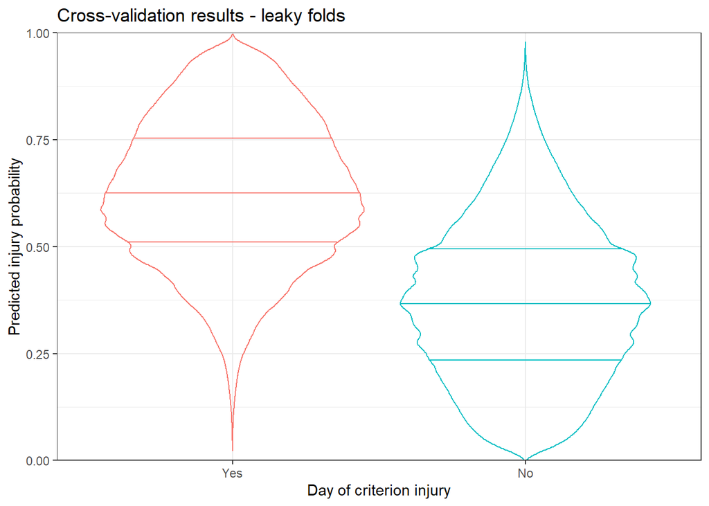

```r
cv_roc_leaky$obs <- factor(cv_roc_leaky$obs, levels = c("Yes", "No"))

ggplot(cv_roc_leaky, aes(x=obs, y=prob_yes, color = obs)) + geom_violin(fill=NA, draw_quantiles = c(0.25, 0.5, 0.75))  + ggtitle("Cross-validation results - leaky folds") + xlab("Day of criterion injury") + ylab("Predicted injury probability") +ggplot_theme+ theme(legend.position ="none") +scale_y_continuous(limits = c(0,1),expand = c(0,0))
```